# Physiological State Classification for Wearable Health Monitoring Using Multimodal Sensor Data

**Randal Burks** | **Nyla Blagrove** | **Madison Honore**  
CSE 881 — Data Mining · Michigan State University · Spring 2026

## Abstract

The goal of this project is to develop a multimodal machine learning framework for classifying physiological states — acute stress, aerobic exercise, and anaerobic exercise — using wearable sensor data sourced from the PhysioNet Wearable Device Dataset (Hongn et al., 2025). The dataset contains synchronized time-series signals recorded with the Empatica E4 wristband, including blood volume pulse (BVP), electrodermal activity (EDA), three-axis accelerometry (ACC), skin temperature (TEMP), heart rate (HR), and inter-beat intervals (IBI), collected from healthy volunteers under controlled laboratory conditions. Signals are recorded at heterogeneous sampling frequencies (64 Hz BVP, 32 Hz ACC, 4 Hz EDA and TEMP) and require non-trivial temporal alignment, session segmentation, subject-level normalization, and fixed-length window construction before modeling. We implement a custom physiological feature extraction pipeline computing heart rate variability metrics (RMSSD, SDNN, pNN50), electrodermal statistics, motion-based features, and temperature dynamics. Three classical machine learning classifiers — Logistic Regression, Random Forest, and Gradient Boosting — are trained and compared under leave-one-subject-out cross-validation to assess generalization to unseen individuals. Results are evaluated via accuracy, macro-averaged precision, recall, F1-score, and confusion matrices, providing a rigorous comparison of model performance across the three physiological state classes.

**Keywords:** physiological state classification, wearable sensor data, heart rate variability, electrodermal activity, leave-one-subject-out validation, multimodal machine learning

## 1. Introduction

Wearable biosensor technology has enabled continuous, non-invasive monitoring of physiological signals in free-living environments. Devices such as the Empatica E4 capture multiple synchronized biosignals that reflect the state of the autonomic nervous system, cardiovascular activity, and musculoskeletal effort. Automatically classifying physiological states from these signals has broad clinical and practical significance: it enables adaptive health monitoring, informs chronic disease management systems, and supports real-time feedback for athletic training.

Three physiological states are of particular relevance in this work. **Acute stress** is a psychological and neurophysiological response to cognitive or emotional challenge, mediated primarily by the sympathetic nervous system. It produces characteristic increases in electrodermal activity, heart rate elevation, and suppression of heart rate variability. **Aerobic exercise** involves sustained, rhythmic physical effort at moderate-to-high intensity, producing progressive cardiovascular demand, gradual temperature rise from thermoregulatory vasodilation, and substantial accelerometer activity reflecting cyclical limb movement. **Anaerobic exercise** consists of short-duration, maximal-intensity bursts of physical effort, producing explosive accelerometer signals, rapid heart rate elevation, and pronounced sweat response.

Despite these distinct physiological signatures, automated classification remains challenging for several reasons. First, stress and aerobic exercise share the common phenotype of elevated heart rate, requiring multi-channel features to discriminate. Second, the wearable signals are recorded at different frequencies and must be temporally aligned before any window-level analysis is possible. Third, the substantial inter-subject physiological variability — in resting heart rate, baseline EDA, and skin temperature — means that classifiers trained on one individual may not generalize to another unless normalization is applied at the subject level.

This project addresses these challenges through a complete end-to-end pipeline: multi-rate signal alignment, subject-level normalization, sliding-window segmentation, physiologically grounded feature extraction, and rigorous cross-subject model evaluation. The remainder of this paper is organized as follows. Section 2 reviews related work on physiological state classification from wearable data. Section 3 formalizes the problem statement. Section 4 describes the full methodology. Section 5 presents the experimental evaluation. Section 6 discusses findings and limitations. Section 7 concludes with directions for future work.

## 2. Related Work

Research on physiological state classification from wearable data spans three primary areas: stress detection, exercise type recognition, and multimodal fusion for combined state discrimination.

### 2.1 Stress Detection from Physiological Signals

Electrodermal activity has been one of the most studied single-channel stress biomarkers due to its exclusive sympathetic nervous system innervation. Healey and Picard [1] demonstrated that EDA, combined with HR and EMG, could classify driver stress from a wearable device with greater than 97% accuracy in a controlled study. Schmidt et al. [2] introduced the WESAD dataset, a widely used benchmark for wearable stress and affect detection using the Empatica E4, establishing that EDA and BVP-derived features are the most discriminative channels for binary stress versus non-stress classification. Gjoreski et al. [3] showed that short-term HRV features, particularly RMSSD and pNN50, provide robust stress indicators when combined with EDA statistics, outperforming single-modality approaches.

### 2.2 Exercise State Recognition

Physical activity recognition from accelerometer data is a mature research area [4], with studies demonstrating that the magnitude, variance, and spectral energy of acceleration signals can reliably distinguish walking, running, cycling, and rest. For exercise intensity classification, Spierer et al. [5] showed that wrist-worn accelerometry combined with heart rate achieves high accuracy in classifying aerobic versus anaerobic effort. Parak and Korhonen [6] demonstrated that the combination of BVP-derived HR and accelerometry provides complementary information for distinguishing exercise intensity levels, with HRV features providing additional discriminative power at submaximal exercise levels.

### 2.3 Joint Stress and Exercise Classification

Fewer studies have tackled the combined discrimination of stress, aerobic exercise, and anaerobic exercise from a single wearable device. Reiss and Stricker [7] proposed a multi-sensor fusion approach for activity and affect recognition but did not include anaerobic exercise protocols. The dataset used in this project — introduced by Hongn et al. [8] — is specifically designed to address this gap, providing the first publicly available dataset with controlled stress induction and both aerobic and anaerobic exercise protocols recorded under the same wearable platform. The present work extends pilot binary classification results reported by the dataset authors [8] to the full three-class problem, with rigorous leave-one-subject-out evaluation.

*References are listed in Section 8.*

## 3. Problem Statement

Let $\mathcal{D} = \{(X_i, y_i)\}_{i=1}^{N}$ denote the full labeled dataset, where each sample $X_i \in \mathbb{R}^{T \times C}$ is a fixed-length time window of $T$ time steps across $C$ physiological signal channels, and $y_i \in \mathcal{Y} = \{\text{stress},\ \text{aerobic},\ \text{anaerobic}\}$ is the corresponding physiological state label.

The classification objective is to learn a function $f: \mathbb{R}^{T \times C} \rightarrow \mathcal{Y}$ that maps a multimodal sensor window to its physiological state label. In practice, $f$ operates on a feature vector $\phi(X_i) \in \mathbb{R}^d$ extracted from the raw window, where $\phi$ is a hand-designed physiological feature extractor.

### Generalization Requirement

The primary scientific requirement is that $f$ generalizes to **subjects not seen during training**. This means that standard random train/test splits are insufficient — they allow windows from the same subject to appear in both the training and test sets, producing artificially inflated performance estimates. Instead, the evaluation protocol uses **Leave-One-Subject-Out (LOSO) cross-validation**, where in each fold $k$, the model is trained on all windows from subjects $\mathcal{S} \setminus \{s_k\}$ and evaluated on all windows from held-out subject $s_k$:

$$f_k = \underset{f}{\arg\min}\ \mathcal{L}\bigl(\{(X_i, y_i) : \text{subject}(X_i) \neq s_k\}\bigr)$$

Final performance is reported by aggregating predictions across all folds.

### Dataset Summary

The dataset originates from three structured experimental sessions recorded using the Empatica E4 wristband:

| Session | Protocol | # Subjects | Duration |
| --- | --- | --- | --- |
| STRESS | Stroop + Trier Mental Challenge tasks | ~36 | ~45 min |
| AEROBIC | Storer-Davis incremental cycling protocol | ~30 | ~35 min |
| ANAEROBIC | Wingate anaerobic sprint protocol (3–4 × 30-45s sprints) | ~31 | ~25 min |

Each session folder contains one subfolder per subject, identified by cohort prefix (`fXX` for V2 cohort, `SXX` for V1 cohort). Some subjects have split sessions stored as `_a` / `_b` subfolders and are treated as independent records in this analysis.

## 4. Methodology

This section describes the complete implementation pipeline, from raw file loading to the final labeled feature matrix that serves as input to the classification models. Each subsection is paired with its corresponding implementation.

### 4.1 Libraries and Configuration

The following libraries support all stages of the pipeline. `numpy` and `pandas` handle array operations and tabular data; `matplotlib` and `seaborn` provide visualization; `scikit-learn` supplies the classifiers, scalers, label encoders, and evaluation metrics.

```python
import warnings
import numpy as np
import pandas as pd
from pathlib import Path
import matplotlib.pyplot as plt
import seaborn as sns
from sklearn.base import clone
from sklearn.preprocessing import StandardScaler, LabelEncoder
from sklearn.linear_model import LogisticRegression
from sklearn.ensemble import RandomForestClassifier, GradientBoostingClassifier
from sklearn.metrics import (
    accuracy_score, f1_score, precision_score,
    recall_score, classification_report, confusion_matrix
)

warnings.filterwarnings('ignore')
plt.rcParams['figure.dpi'] = 120
sns.set_style('whitegrid')
```

### 4.2 Global Parameters

All pipeline parameters are defined in a single location to ensure reproducibility and to make it easy to evaluate the effect of different windowing or resampling choices.

```python
BASE = Path(
    "/Users/randalburks/Downloads/SPRING 2026/881/Project first iteration/"
    "wearable-device-dataset-from-induced-stress-and-structured-exercise-sessions-1.0.1/"
    "Wearable_Dataset"
)

SESSION_PATHS = {
    "stress": BASE / "STRESS",
    "aerobic": BASE / "AEROBIC",
    "anaerobic": BASE / "ANAEROBIC",
}

NATIVE_FS = {
    "BVP": 64,
    "ACC": 32,
    "EDA": 4,
    "TEMP": 4,
    "HR": 1,
}

TARGET_FS = 4
WINDOW_SEC = 30
OVERLAP_FRAC = 0.50
EXCLUDED_IDS = {"S02", "f07"}
```

### 4.3 Data Loading

#### Dataset Inventory

The dataset contains three top-level session directories. Within each, subjects from cohort V1 are labeled `SXX` and subjects from cohort V2 are labeled `fXX`. Known-bad subjects (`S02` — duplicate data; `f07` — wristband cover not removed) are excluded. Split sessions (`f14_a`, `f14_b`, and similar `_a`/`_b` pairs) are treated as independent records rather than being concatenated, since each part has its own continuous timestamp range and constitutes a valid standalone recording segment. The cell below provides a full inventory of available subjects per session.

```python
rows = []
for label, path in SESSION_PATHS.items():
    subjects = sorted([d.name for d in path.iterdir() if d.is_dir()])
    rows.append({
        "Session":       label.capitalize(),
        "Total Folders": len(subjects),
        "Subject IDs":   ", ".join(subjects)
    })

pd.DataFrame(rows).set_index("Session")
```

| Session | Total Folders | Subject IDs |
| --- | --- | --- |
| Stress | 37 | S01, S02, S03, S04, S05, S06, S07, S08, S09, S... |
| Aerobic | 31 | S01, S02, S03, S04, S05, S06, S07, S08, S09, S... |
| Anaerobic | 32 | S01, S02, S03, S04, S05, S06, S07, S08, S09, S... |

#### Signal File Format

Every CSV file exported by the Empatica E4 follows a consistent two-row header convention:

- **Row 0**: the session start time as a Unix UTC timestamp (float) or a human-readable datetime string.
- **Row 1**: the native sampling rate of the signal in Hz (float).
- **Rows 2 onward**: the signal samples. For `ACC.csv` there are three columns (x, y, z); all other files have a single value column.

The `IBI.csv` file is structurally distinct: row 0 holds the start timestamp, and subsequent rows contain pairs of `[time_offset_from_start_in_seconds, IBI_duration_in_seconds]`. Because heartbeats are aperiodic, IBI values cannot be assigned a fixed sampling rate and are retained as a sparse time-stamped table for use during HRV feature extraction.

The `tags.csv` file contains one UTC timestamp per row, each corresponding to a button press marking a protocol phase boundary. In this project, session-level labels are directly inferred from the folder structure (STRESS/AEROBIC/ANAEROBIC) rather than from tag-based intra-session segmentation.

The `parse_timestamp` helper handles both Unix float and datetime string formats uniformly. The `load_signal` function is fully wrapped in a try-except so that any unexpected file format returns `None` without crashing the pipeline.

```python
def parse_timestamp(value):
    try:
        return float(value)
    except (ValueError, TypeError):
        return pd.Timestamp(str(value)).timestamp()


def load_signal(filepath):
    filepath = Path(filepath)
    if not filepath.exists():
        return None

    try:
        raw = pd.read_csv(filepath, header=None)

        if filepath.stem == "IBI":
            start_time = parse_timestamp(raw.iloc[0, 0])
            ibi = raw.iloc[1:].copy().reset_index(drop=True)

            if ibi.shape[1] < 2:
                return None

            ibi = ibi.iloc[:, :2].copy()
            ibi.columns = ["time_offset", "ibi"]
            ibi["time_offset"] = pd.to_numeric(ibi["time_offset"], errors="coerce")
            ibi["ibi"] = pd.to_numeric(ibi["ibi"], errors="coerce")
            ibi = ibi.dropna().reset_index(drop=True)

            if len(ibi) == 0:
                return None

            ibi["timestamp"] = start_time + ibi["time_offset"]
            return ibi[["timestamp", "ibi"]]

        start_time = parse_timestamp(raw.iloc[0, 0])
        sample_rate = float(raw.iloc[1, 0])
        values = raw.iloc[2:].reset_index(drop=True)

        if len(values) < 1:
            return None

        if filepath.stem == "ACC":
            values = values.iloc[:, :3].copy()
            values.columns = ["x", "y", "z"]

            for col in ["x", "y", "z"]:
                values[col] = pd.to_numeric(values[col], errors="coerce")

            values = values.dropna().reset_index(drop=True)
            if len(values) == 0:
                return None

            timestamps = start_time + np.arange(len(values)) / sample_rate

            df = pd.DataFrame({
                "timestamp": timestamps,
                "x": values["x"],
                "y": values["y"],
                "z": values["z"]
            })
            df["magnitude"] = np.sqrt(df["x"]**2 + df["y"]**2 + df["z"]**2)
            return df[["timestamp", "magnitude", "x", "y", "z"]]

        col = filepath.stem.lower()
        vals = pd.to_numeric(values.iloc[:, 0], errors="coerce")
        valid = vals.notna()

        if valid.sum() == 0:
            return None

        vals = vals[valid].reset_index(drop=True)
        timestamps = start_time + np.arange(len(vals)) / sample_rate

        return pd.DataFrame({
            "timestamp": timestamps,
            col: vals
        })

    except Exception:
        return None


def load_tags(filepath):
    filepath = Path(filepath)
    if not filepath.exists():
        return np.array([])

    try:
        raw = pd.read_csv(filepath, header=None)
        return np.array([parse_timestamp(v) for v in raw.iloc[:, 0].values])
    except Exception:
        return np.array([])


def load_subject(subject_path, label):
    subject_path = Path(subject_path)
    subject_id = subject_path.name
    base_subject_id = subject_id.replace("_a", "").replace("_b", "")

    record = {
        "subject_id": subject_id,
        "base_subject_id": base_subject_id,
        "label": label
    }

    for sig in ["BVP", "ACC", "EDA", "TEMP", "HR", "IBI"]:
        record[sig] = load_signal(subject_path / f"{sig}.csv")

    record["tags"] = load_tags(subject_path / "tags.csv")
    return record
```

#### Loading All Subjects

The loader iterates over every subdirectory in each of the three session folders. The `base_id` check strips the `_a` / `_b` suffix before testing against the exclusion list, ensuring that both halves of a split session are excluded if the base subject ID is flagged.

```python
raw_records = []

for label, path in SESSION_PATHS.items():
    for subj_dir in sorted(path.iterdir()):
        if not subj_dir.is_dir():
            continue

        base_id = subj_dir.name.replace("_a", "").replace("_b", "")
        if base_id in EXCLUDED_IDS:
            continue

        raw_records.append(load_subject(subj_dir, label))

load_summary = (
    pd.DataFrame([{"Label": r["label"].capitalize(), "Subject": r["subject_id"]}
                  for r in raw_records])
    .groupby("Label")["Subject"]
    .agg(["count", list])
    .rename(columns={"count": "Records", "list": "Subject IDs"})
)
print(f"Total records loaded: {len(raw_records)}")
load_summary
```

```
Total records loaded: 94
```

| Label | Records | Subject IDs |
| --- | --- | --- |
| Aerobic | 29 | [S01, S03, S04, S05, S06, S07, S08, S09, S10, ... |
| Anaerobic | 30 | [S01, S03, S04, S05, S06, S07, S08, S09, S10, ... |
| Stress | 35 | [S01, S03, S04, S05, S06, S07, S08, S09, S10, ... |

#### Raw Signal Preview

Before preprocessing, it is instructive to examine the raw signals as recorded by the device. The plot below shows 90 seconds of raw EDA, TEMP, HR, and BVP from a representative subject. The signals reflect the Empatica E4's native sampling rates and absolute physiological values — differences in scale and sampling density across channels underscore the need for temporal alignment before any window-based analysis.

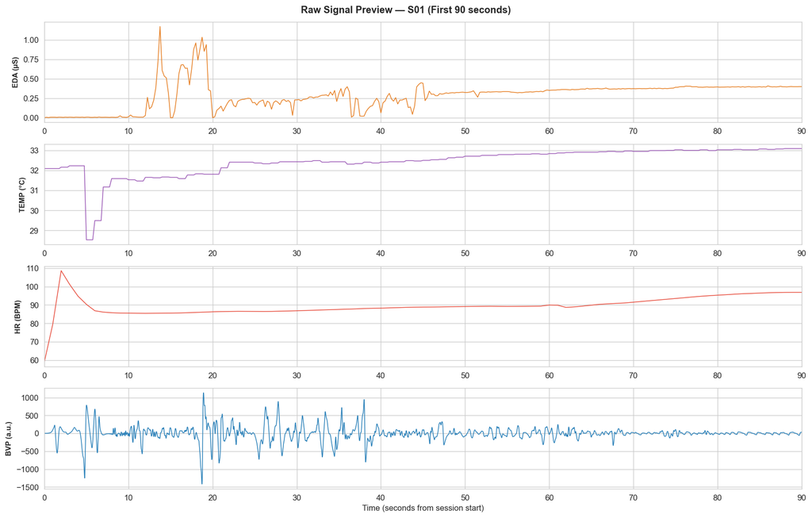

```python
signal_specs = [
    ("EDA", "eda", "#e67e22", "EDA (µS)"),
    ("TEMP", "temp", "#9b59b6", "TEMP (°C)"),
    ("HR", "hr", "#e74c3c", "HR (BPM)"),
    ("BVP", "bvp", "#2980b9", "BVP (a.u.)"),
]

sample_record = None
for rec in raw_records:
    if all(rec.get(sig) is not None and len(rec.get(sig)) > 1 for sig in ["EDA", "TEMP", "HR", "BVP"]):
        sample_record = rec
        break

if sample_record is not None:
    fig, axes = plt.subplots(4, 1, figsize=(14, 9), sharex=False)

    for ax, (sig_name, col_name, color, ylabel) in zip(axes, signal_specs):
        df = sample_record.get(sig_name)

        if df is not None and len(df) > 1 and col_name in df.columns:
            t0 = df["timestamp"].iloc[0]
            preview = df[df["timestamp"] <= t0 + 90].copy()
            ax.plot(preview["timestamp"] - t0, preview[col_name], color=color, linewidth=0.9)
        else:
            ax.text(0.5, 0.5, f"{sig_name} unavailable", ha="center", va="center", transform=ax.transAxes)

        ax.set_ylabel(ylabel, fontsize=9, fontweight="bold")
        ax.margins(x=0)

    axes[-1].set_xlabel("Time (seconds from session start)", fontsize=10)
    fig.suptitle(
        f"Raw Signal Preview — {sample_record['subject_id']} (First 90 seconds)",
        fontsize=12,
        fontweight="bold"
    )
    plt.tight_layout()
    plt.show()
else:
    print("No sample subject available for raw signal preview.")
```

### 4.4 Preprocessing

#### Signal Alignment

The five primary channels (BVP, EDA, TEMP, HR, ACC) are sampled at four distinct rates, making direct multi-channel analysis impossible without a common time axis. The alignment procedure applies three steps:

Any record whose overlap interval is shorter than one window (30 seconds) is discarded.

#### Subject-Level Z-Score Normalization

After alignment, each channel of each subject's DataFrame is independently normalized to zero mean and unit variance using that subject's own statistics. This step eliminates inter-individual differences in absolute physiological baselines — resting heart rate, skin conductance level, and body temperature vary substantially across healthy adults — that would otherwise allow a classifier to partially learn subject identity rather than physiological state. Crucially, normalization is applied per subject *before* windowing, ensuring that the scaler sees only that subject's data and cannot introduce cross-subject information.

```python
def align_signals(record, target_fs=TARGET_FS):
    signal_map = {}

    for sig_name in ["BVP", "EDA", "TEMP", "HR"]:
        df = record.get(sig_name)
        if df is not None and len(df) > 1:
            col = [c for c in df.columns if c != "timestamp"][0]
            df_clean = df[["timestamp", col]].dropna(subset=["timestamp"])
            if len(df_clean) > 1:
                signal_map[sig_name.lower()] = df_clean

    acc_df = record.get("ACC")
    if acc_df is not None and len(acc_df) > 1:
        acc_clean = acc_df[["timestamp", "magnitude"]].dropna(subset=["timestamp"])
        if len(acc_clean) > 1:
            signal_map["acc_mag"] = acc_clean.rename(columns={"magnitude": "acc_mag"})

    if len(signal_map) < 2:
        return None

    t_start = max(df["timestamp"].min() for df in signal_map.values())
    t_end   = min(df["timestamp"].max() for df in signal_map.values())

    if t_end - t_start < WINDOW_SEC:
        return None

    common_t = np.arange(t_start, t_end, 1.0 / target_fs)
    aligned  = pd.DataFrame({"timestamp": common_t})

    for col_name, df in signal_map.items():
        val_col = [c for c in df.columns if c != "timestamp"][0]
        aligned[col_name] = np.interp(
            common_t,
            df["timestamp"].values,
            df[val_col].values.astype(float)
        )

    return aligned


def normalize_signals(df):
    df = df.copy()
    for col in [c for c in df.columns if c != "timestamp"]:
        std = df[col].std()
        df[col] = (df[col] - df[col].mean()) / std if std > 1e-9 else 0.0
    return df
```

```python
aligned_records = []

for record in raw_records:
    aligned = align_signals(record)
    if aligned is None:
        continue

    normalized = normalize_signals(aligned)

    aligned_records.append({
        "subject_id": record["subject_id"],
        "base_subject_id": record["base_subject_id"],
        "label": record["label"],
        "data": normalized,
        "ibi": record.get("IBI"),
    })

preproc_summary = (
    pd.DataFrame([{
        "Label": r["label"].capitalize(),
        "Subject": r["subject_id"],
        "Base Subject": r["base_subject_id"],
        "Channels": len([c for c in r["data"].columns if c != "timestamp"]),
        "Duration (min)": round(len(r["data"]) / TARGET_FS / 60, 1),
    } for r in aligned_records])
    .groupby("Label")
    .agg(
        Records=("Subject", "count"),
        Avg_Duration=("Duration (min)", "mean"),
        Channels=("Channels", "first")
    )
    .round(1)
)

print(f"Records successfully preprocessed: {len(aligned_records)}")
preproc_summary
```

```
Records successfully preprocessed: 94
```

| Label | Records | Avg_Duration | Channels |
| --- | --- | --- | --- |
| Aerobic | 29 | 35.1 | 5 |
| Anaerobic | 30 | 25.7 | 5 |
| Stress | 35 | 41.0 | 5 |

### 4.5 Segmentation and Label Assignment

#### Window Design

Each preprocessed, normalized session is segmented into fixed-length windows using a sliding window approach. The key design parameters are:

- **Window length: 30 seconds** (120 samples at 4 Hz). This duration is the minimum recommended for reliable short-term HRV analysis, which requires enough heartbeats to produce statistically stable estimates of RMSSD and pNN50. A 30-second window at typical resting heart rate (~70 BPM) contains approximately 35 inter-beat intervals, which is sufficient for short-term HRV computation.
- **Overlap: 50%** (15-second step, 60-sample stride). The 50% overlap increases the effective number of windows per session, reducing the impact of boundary artifacts and providing more training samples for the classifiers. It is standard practice in physiological time-series segmentation.

Windows shorter than the full 120 samples (arising at the end of a session) are discarded rather than zero-padded, to avoid introducing artificial signal discontinuities.

#### Label Assignment

Each window is assigned the session-level label of the subject from which it was extracted. This label is inherited directly from the folder structure established during data loading:

- Windows from `STRESS/` subjects → label `stress`
- Windows from `AEROBIC/` subjects → label `aerobic`
- Windows from `ANAEROBIC/` subjects → label `anaerobic`

The IBI table is passed alongside each window record so that HRV features can be extracted from the heartbeats that fall within the window's absolute timestamp range, independent of the fixed-rate resampling applied to the other channels.

```python
WINDOW_SAMPLES = int(WINDOW_SEC * TARGET_FS)
STEP_SAMPLES = int(WINDOW_SAMPLES * (1 - OVERLAP_FRAC))

def create_windows(record):
    df = record["data"]
    label = record["label"]
    subject_id = record["subject_id"]
    base_subject_id = record["base_subject_id"]
    ibi = record.get("ibi")
    n = len(df)
    windows = []

    for start in range(0, n - WINDOW_SAMPLES + 1, STEP_SAMPLES):
        end = start + WINDOW_SAMPLES
        segment = df.iloc[start:end]

        windows.append({
            "subject_id": subject_id,
            "base_subject_id": base_subject_id,
            "label": label,
            "window": segment.reset_index(drop=True),
            "ibi": ibi,
            "t_start": float(segment["timestamp"].iloc[0]),
            "t_end": float(segment["timestamp"].iloc[-1]),
        })

    return windows
```

```python
all_windows = []
for rec in aligned_records:
    all_windows.extend(create_windows(rec))

window_summary = (
    pd.Series([w["label"] for w in all_windows])
    .value_counts()
    .rename("Window Count")
    .to_frame()
    .assign(
        Pct=lambda df: (df["Window Count"] / df["Window Count"].sum() * 100)
    )
)

print(f"Total windows: {len(all_windows):,}")
print(f"Window length: {WINDOW_SEC}s | Overlap: {int(OVERLAP_FRAC*100)}% | Step: {int(STEP_SAMPLES / TARGET_FS)}s")
window_summary
```

```
Total windows: 12,757
Window length: 30s | Overlap: 50% | Step: 15s
```

|  | Window Count | Pct |
| --- | --- | --- |
| stress | 5684 | 44.55593 |
| aerobic | 4038 | 31.65321 |
| anaerobic | 3035 | 23.79086 |

### 4.6 Feature Engineering

Rather than using raw signal arrays as classifier input, each 30-second window is transformed into a compact, physiologically interpretable feature vector. This approach is appropriate for classical machine learning models and produces features that are directly interpretable in terms of known stress and exercise physiology.

#### Heart Rate Variability (HRV) from IBI

HRV measures the fluctuation in the time between consecutive heartbeats and is a well-established index of autonomic nervous system balance. Parasympathetic dominance (rest) produces high HRV; sympathetic activation (stress, intense exercise) suppresses it. Four standard time-domain HRV metrics are computed from the IBI intervals whose timestamps fall within each window's absolute time range:

| Feature | Description |
| --- | --- |
| `hrv_rmssd` | Root mean square of successive IBI differences — most sensitive to short-term parasympathetic modulation |
| `hrv_sdnn` | Standard deviation of all IBIs — reflects overall autonomic variability |
| `hrv_mean_hr` | Mean heart rate in BPM, derived as 60 / mean(IBI) |
| `hrv_pnn50` | Percentage of successive differences > 50 ms — a robust parasympathetic index |

If fewer than 3 IBI values fall within a window's time range (e.g., due to signal dropout), all HRV features are set to `NaN` and subsequently imputed with the column median.

#### Electrodermal Activity (EDA)

EDA is driven exclusively by eccrine sweat glands under sympathetic nervous system control, making it the most specific non-cardiac biomarker of psychological arousal. Five features capture the amplitude and trajectory of the EDA signal within the window: mean, standard deviation, minimum, maximum, and linear slope. The slope is particularly informative because EDA rises during stress onset and decays slowly during recovery.

#### Accelerometer Magnitude (ACC)

The three-axis acceleration magnitude summarizes total body movement intensity. Mean and standard deviation capture average and variable motion; energy (sum of squared values) captures burst-type activity characteristic of anaerobic sprints; maximum captures peak acceleration; slope captures whether motion is accelerating or decelerating.

#### Skin Temperature (TEMP)

Temperature responds slowly and is most informative for distinguishing aerobic exercise (progressive thermoregulatory rise) from stress (possible vasoconstriction at the periphery). Mean, standard deviation, and slope are computed.

#### Blood Volume Pulse (BVP) and Heart Rate (HR)

BVP mean, standard deviation, and amplitude range complement the IBI-derived HR features. HR mean, standard deviation, and slope characterize the cardiovascular response level and trajectory.

```python
def safe_slope(series):
    if series is None or len(series) < 2:
        return 0.0
    x = np.arange(len(series), dtype=float)
    s = series.values.astype(float)
    return float(np.polyfit(x, s, 1)[0])


def hrv_features(ibi_data, t_start, t_end):
    nan_out = {
        "hrv_rmssd": np.nan,
        "hrv_sdnn": np.nan,
        "hrv_mean_hr": np.nan,
        "hrv_pnn50": np.nan,
    }

    if ibi_data is None or len(ibi_data) == 0:
        return nan_out

    mask = (ibi_data["timestamp"] >= t_start) & (ibi_data["timestamp"] <= t_end)
    ibis = ibi_data.loc[mask, "ibi"].values.astype(float)

    if len(ibis) < 3:
        return nan_out

    diffs = np.diff(ibis)

    return {
        "hrv_rmssd": float(np.sqrt(np.mean(diffs ** 2))),
        "hrv_sdnn": float(np.std(ibis, ddof=1)),
        "hrv_mean_hr": float(60.0 / np.mean(ibis)) if np.mean(ibis) > 0 else np.nan,
        "hrv_pnn50": float(100.0 * np.mean(np.abs(diffs) > 0.05)),
    }


def eda_features(series):
    return {
        "eda_mean": float(series.mean()),
        "eda_std": float(series.std()),
        "eda_min": float(series.min()),
        "eda_max": float(series.max()),
        "eda_slope": safe_slope(series),
    }


def acc_features(series):
    s = series.values.astype(float)
    return {
        "acc_mean": float(series.mean()),
        "acc_std": float(series.std()),
        "acc_energy": float(np.sum(s ** 2)),
        "acc_max": float(series.max()),
        "acc_slope": safe_slope(series),
    }


def temp_features(series):
    return {
        "temp_mean": float(series.mean()),
        "temp_std": float(series.std()),
        "temp_slope": safe_slope(series),
    }


def bvp_features(series):
    return {
        "bvp_mean": float(series.mean()),
        "bvp_std": float(series.std()),
        "bvp_range": float(series.max() - series.min()),
    }


def hr_features(series):
    return {
        "hr_mean": float(series.mean()),
        "hr_std": float(series.std()),
        "hr_slope": safe_slope(series),
    }


def extract_features(win_record):
    w = win_record["window"]

    row = {
        "subject_id": win_record["subject_id"],
        "base_subject_id": win_record["base_subject_id"],
        "label": win_record["label"]
    }

    if "eda" in w.columns:
        row.update(eda_features(w["eda"]))
    if "acc_mag" in w.columns:
        row.update(acc_features(w["acc_mag"]))
    if "temp" in w.columns:
        row.update(temp_features(w["temp"]))
    if "bvp" in w.columns:
        row.update(bvp_features(w["bvp"]))
    if "hr" in w.columns:
        row.update(hr_features(w["hr"]))

    row.update(hrv_features(win_record["ibi"], win_record["t_start"], win_record["t_end"]))
    return row


feature_rows = [extract_features(w) for w in all_windows]
feature_df = pd.DataFrame(feature_rows)

META_COLS = ["subject_id", "base_subject_id", "label"]
NON_FEATURE_COLS = META_COLS.copy()

FEATURE_COLS = [c for c in feature_df.columns if c not in NON_FEATURE_COLS]

numeric_block = feature_df[FEATURE_COLS].apply(pd.to_numeric, errors="coerce")
feature_df[FEATURE_COLS] = numeric_block.fillna(numeric_block.median())

le = LabelEncoder()
feature_df["label_enc"] = le.fit_transform(feature_df["label"])

FEATURE_COLS = [c for c in feature_df.columns if c not in META_COLS + ["label_enc"]]

print(f"Unique subject_id values: {feature_df['subject_id'].nunique()}")
print(f"Unique base_subject_id values: {feature_df['base_subject_id'].nunique()}")
print(f"Feature matrix : {feature_df.shape[0]:,} windows × {len(FEATURE_COLS)} features")
print(f"Classes : {list(le.classes_)}")
print(f"Missing values : {feature_df[FEATURE_COLS].isna().sum().sum()}")
print("Feature columns:")
print(FEATURE_COLS)

feature_df[FEATURE_COLS].describe().round(4)
```

```
Unique subject_id values: 39
Unique base_subject_id values: 34
Feature matrix : 12,757 windows × 23 features
Classes : ['aerobic', 'anaerobic', 'stress']
Missing values : 0
Feature columns:
['eda_mean', 'eda_std', 'eda_min', 'eda_max', 'eda_slope', 'acc_mean', 'acc_std', 'acc_energy', 'acc_max', 'acc_slope', 'temp_mean', 'temp_std', 'temp_slope', 'bvp_mean', 'bvp_std', 'bvp_range', 'hr_mean', 'hr_std', 'hr_slope', 'hrv_rmssd', 'hrv_sdnn', 'hrv_mean_hr', 'hrv_pnn50']
```

|  | eda_mean | eda_std | eda_min | eda_max | eda_slope | acc_mean | acc_std | acc_energy | acc_max | acc_slope | ... | bvp_mean | bvp_std | bvp_range | hr_mean | hr_std | hr_slope | hrv_rmssd | hrv_sdnn | hrv_mean_hr | hrv_pnn50 |
| --- | --- | --- | --- | --- | --- | --- | --- | --- | --- | --- | --- | --- | --- | --- | --- | --- | --- | --- | --- | --- | --- |
| count | 12757.0000 | 12757.0000 | 12757.0000 | 12757.0000 | 12757.0000 | 12757.0000 | 12757.0000 | 12757.0000 | 12757.0000 | 12757.0000 | ... | 12757.0000 | 12757.0000 | 12757.0000 | 12757.0000 | 12757.0000 | 12757.0000 | 12757.0000 | 12757.0000 | 12757.0000 | 12757.0000 |
| mean | -0.0013 | 0.1095 | -0.2357 | 0.2409 | 0.0002 | -0.0006 | 0.7322 | 118.2854 | 3.5123 | -0.0000 | ... | 0.0000 | 0.8979 | 6.0807 | 0.0021 | 0.1296 | 0.0001 | 0.0519 | 0.0493 | 90.3371 | 23.1652 |
| std | 0.9739 | 0.1750 | 0.9480 | 1.2155 | 0.0036 | 0.2211 | 0.6392 | 276.4488 | 4.0589 | 0.0032 | ... | 0.0307 | 0.4411 | 4.0188 | 0.9734 | 0.1388 | 0.0051 | 0.0331 | 0.0291 | 22.0839 | 20.1825 |
| min | -3.5900 | 0.0000 | -4.9345 | -3.1823 | -0.0490 | -3.8306 | 0.0000 | 0.0421 | -3.6077 | -0.0288 | ... | -0.2902 | 0.0000 | 0.0000 | -5.6605 | 0.0005 | -0.0320 | 0.0000 | 0.0000 | 39.8961 | 0.0000 |
| 25% | -0.7270 | 0.0221 | -0.8587 | -0.6574 | -0.0006 | -0.1065 | 0.2815 | 14.6592 | 0.8630 | -0.0011 | ... | -0.0141 | 0.5945 | 3.1925 | -0.6861 | 0.0402 | -0.0020 | 0.0354 | 0.0343 | 78.4245 | 10.2564 |
| 50% | -0.2055 | 0.0565 | -0.4413 | 0.0177 | 0.0000 | -0.0187 | 0.5654 | 41.9181 | 2.2049 | -0.0000 | ... | 0.0002 | 0.8292 | 5.2527 | -0.1329 | 0.0849 | 0.0000 | 0.0449 | 0.0446 | 85.0893 | 18.7500 |
| 75% | 0.6848 | 0.1292 | 0.4175 | 0.9990 | 0.0009 | 0.0902 | 0.9924 | 120.4884 | 4.6347 | 0.0011 | ... | 0.0141 | 1.1191 | 7.8959 | 0.5901 | 0.1707 | 0.0021 | 0.0560 | 0.0560 | 94.6479 | 30.0000 |
| max | 4.3514 | 3.2988 | 4.1623 | 22.2390 | 0.0459 | 1.6031 | 8.9757 | 9589.5817 | 46.3512 | 0.0491 | ... | 0.3339 | 5.6251 | 49.3047 | 5.6977 | 2.2899 | 0.0626 | 0.5277 | 0.3797 | 187.3171 | 100.0000 |

8 rows × 23 columns

#### Feature Distribution by Class

The histograms below illustrate the per-class distribution of six key features after subject-level normalization. These plots reveal the degree of class separation in the feature space before any classifier is applied. Clear distributional separation between classes in a feature indicates strong discriminative potential; overlapping distributions indicate where classifiers will encounter difficulty.

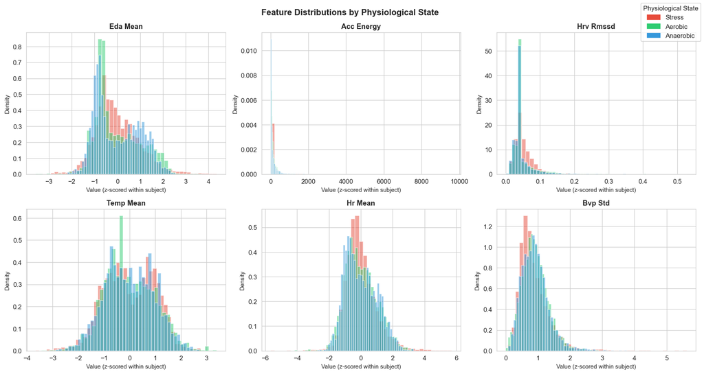

```python
plot_feats = ["eda_mean", "acc_energy", "hrv_rmssd", "temp_mean", "hr_mean", "bvp_std"]
available  = [f for f in plot_feats if f in feature_df.columns]
palette    = {"stress": "#e74c3c", "aerobic": "#2ecc71", "anaerobic": "#3498db"}

fig, axes = plt.subplots(2, 3, figsize=(15, 8))
for ax, feat in zip(axes.flatten(), available):
    for label, color in palette.items():
        vals = feature_df[feature_df["label"] == label][feat].dropna()
        ax.hist(vals, bins=45, alpha=0.50, color=color, label=label.capitalize(), density=True)
    ax.set_title(feat.replace("_", " ").title(), fontsize=11, fontweight="bold")
    ax.set_xlabel("Value (z-scored within subject)", fontsize=9)
    ax.set_ylabel("Density", fontsize=9)

handles = [plt.Rectangle((0, 0), 1, 1, color=c) for c in palette.values()]
fig.legend(handles, [l.capitalize() for l in palette], loc="upper right",
           fontsize=10, title="Physiological State", title_fontsize=10)
fig.suptitle("Feature Distributions by Physiological State", fontsize=13, fontweight="bold")
plt.tight_layout()
plt.show()
```

## 5. Experimental Evaluation

### 5.1 Experimental Setup

#### Validation Protocol: Leave-One-Subject-Out Cross-Validation

All models are evaluated under **Leave-One-Subject-Out (LOSO)** cross-validation. In each of $K$ folds (one per unique subject identifier), the held-out subject's windows form the test set, and windows from all remaining subjects form the training set. A fresh `StandardScaler` is fit on the training feature matrix in each fold and applied to both train and test sets — this is critical because it ensures that no test-subject statistics are used during normalization, which would constitute a form of data leakage.

#### Computing Environment

All experiments run on a standard Python 3.9 environment with scikit-learn ≥ 1.2, numpy ≥ 1.23, and pandas ≥ 1.5. No GPU is required.

### 5.2 Models

**Random Forest (RF)** is an ensemble of 150 decision trees, each trained on a bootstrap sample and a random subset of features. The ensemble vote aggregates tree predictions, reducing variance and handling non-linear feature interactions that are invisible to logistic regression. Feature importances, measured by mean decrease in Gini impurity averaged across all trees and LOSO folds, provide a ranking of the most discriminative physiological features.

**Gradient Boosting (GB)** builds an additive ensemble of 150 shallow trees (max depth 4), where each successive tree fits the pseudo-residuals of the current ensemble. This iterative residual correction allows it to model complex decision boundaries and typically achieves the highest accuracy on structured tabular physiological data, at the cost of longer training time.

```python
CLASSIFIERS = {
    "Logistic Regression": LogisticRegression(
        max_iter=2000, class_weight="balanced", random_state=42
    ),
    "Random Forest": RandomForestClassifier(
        n_estimators=150, class_weight="balanced",
        random_state=42, n_jobs=-1
    ),
    "Gradient Boosting": GradientBoostingClassifier(
        n_estimators=150, learning_rate=0.1,
        max_depth=4, random_state=42
    ),
}
```

```python
subjects = feature_df["base_subject_id"].unique()
y_true = []
y_pred = {name: [] for name in CLASSIFIERS}
rf_imp_acc = np.zeros(len(FEATURE_COLS))

for subj in subjects:
    test_mask = feature_df["base_subject_id"] == subj
    train_mask = ~test_mask

    X_train = feature_df.loc[train_mask, FEATURE_COLS].values
    y_train = feature_df.loc[train_mask, "label_enc"].values
    X_test = feature_df.loc[test_mask, FEATURE_COLS].values
    y_test = feature_df.loc[test_mask, "label_enc"].values

    scaler = StandardScaler()
    X_train_s = scaler.fit_transform(X_train)
    X_test_s = scaler.transform(X_test)

    y_true.extend(y_test.tolist())

    for name, clf_template in CLASSIFIERS.items():
        clf = clone(clf_template)
        clf.fit(X_train_s, y_train)
        y_pred[name].extend(clf.predict(X_test_s).tolist())

        if name == "Random Forest":
            rf_imp_acc += clf.feature_importances_

y_true      = np.array(y_true)
rf_imp_acc /= len(subjects)
for name in y_pred:
    y_pred[name] = np.array(y_pred[name])

print(f"LOSO complete — {len(subjects)} folds | {len(y_true):,} total test-set windows evaluated")
```

```
LOSO complete — 34 folds | 12,757 total test-set windows evaluated
```

### 5.3 Evaluation Metrics

Performance is quantified using five complementary metrics:

- **Accuracy**: fraction of windows correctly classified across all classes and all held-out folds. Provides an overall success rate but can mask per-class imbalance.
- **Precision (macro)**: unweighted mean of per-class precision values. Precision for a class $c$ is $TP_c / (TP_c + FP_c)$ — the fraction of windows predicted as class $c$ that truly belong to class $c$. A low precision indicates many false alarms for that class.
- **Recall (macro)**: unweighted mean of per-class recall values. Recall for class $c$ is $TP_c / (TP_c + FN_c)$ — the fraction of true class $c$ windows that were correctly detected.
- **F1 Macro**: harmonic mean of macro precision and recall. The macro average treats all classes equally, making it the most appropriate summary metric when all three physiological states are equally important.
- **F1 Weighted**: frequency-weighted F1, accounting for class size differences across sessions.

The **confusion matrix** visualizes the full pattern of correct and incorrect classifications. Values are normalized as percentages of each true class (row-normalized), so the matrix is interpretable regardless of class size differences.

```python
rows = []
for name, preds in y_pred.items():
    rows.append({
        "Model":         name,
        "Accuracy":      round(accuracy_score(y_true, preds), 4),
        "Precision":     round(precision_score(y_true, preds, average="macro",    zero_division=0), 4),
        "Recall":        round(recall_score(   y_true, preds, average="macro",    zero_division=0), 4),
        "F1 (Macro)":    round(f1_score(       y_true, preds, average="macro",    zero_division=0), 4),
        "F1 (Weighted)": round(f1_score(       y_true, preds, average="weighted", zero_division=0), 4),
    })

results_df = pd.DataFrame(rows).set_index("Model")
results_df
```

| Model | Accuracy | Precision | Recall | F1 (Macro) | F1 (Weighted) |
| --- | --- | --- | --- | --- | --- |
| Logistic Regression | 0.6368 | 0.6007 | 0.6007 | 0.6007 | 0.6370 |
| Random Forest | 0.7096 | 0.6709 | 0.6674 | 0.6683 | 0.7051 |
| Gradient Boosting | 0.7111 | 0.6729 | 0.6716 | 0.6720 | 0.7084 |

### 5.4 Results

#### Confusion Matrices

The confusion matrices below display the LOSO classification results for all three models. Each entry shows the percentage of windows from the true class (row) that were predicted as each class (column). Diagonal entries are correct predictions; off-diagonal entries indicate systematic misclassification patterns.

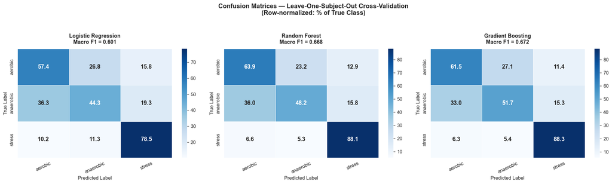

```python
class_names = le.classes_
fig, axes   = plt.subplots(1, 3, figsize=(18, 5))

for ax, (name, preds) in zip(axes, y_pred.items()):
    cm     = confusion_matrix(y_true, preds)
    cm_pct = cm.astype(float) / cm.sum(axis=1, keepdims=True) * 100

    sns.heatmap(
        cm_pct,
        annot=True, fmt=".1f", cmap="Blues",
        xticklabels=class_names, yticklabels=class_names,
        ax=ax, linewidths=0.5, cbar=True,
        annot_kws={"size": 12, "weight": "bold"}
    )
    f1 = f1_score(y_true, preds, average="macro", zero_division=0)
    ax.set_title(f"{name}\nMacro F1 = {f1:.3f}", fontsize=11, fontweight="bold", pad=10)
    ax.set_xlabel("Predicted Label", fontsize=10)
    ax.set_ylabel("True Label", fontsize=10)
    ax.tick_params(axis="x", rotation=25)

plt.suptitle(
    "Confusion Matrices — Leave-One-Subject-Out Cross-Validation\n(Row-normalized: % of True Class)",
    fontsize=13, fontweight="bold", y=1.04
)
plt.tight_layout()
plt.savefig("confusion_matrices.png", dpi=150, bbox_inches="tight")
plt.show()
```

#### Feature Importance Analysis

The Random Forest model provides mean decrease in impurity (MDI) feature importances, averaged across all LOSO training folds. The chart below ranks the top 15 features by their average contribution to correct classification. This analysis identifies which physiological channels and which specific statistics are most discriminative across the three-class problem.

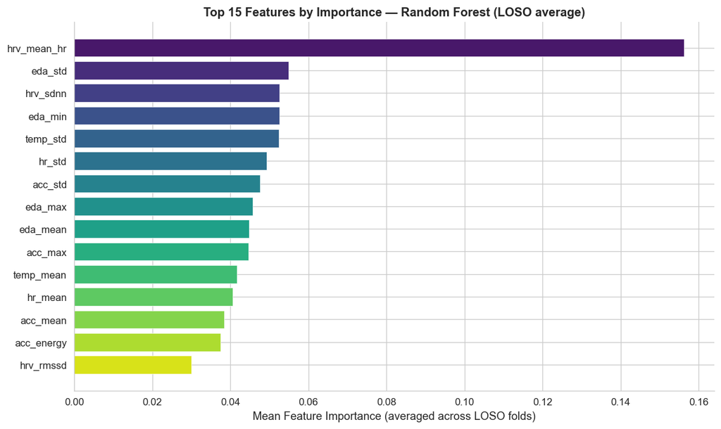

```python
rf_importance = (
    pd.Series(rf_imp_acc, index=FEATURE_COLS)
    .sort_values(ascending=False)
)

fig, ax = plt.subplots(figsize=(10, 6))
colors  = sns.color_palette("viridis", 15)
ax.barh(rf_importance[:15].index[::-1], rf_importance[:15].values[::-1],
        color=colors[::-1], edgecolor="white", linewidth=0.4)
ax.set_xlabel("Mean Feature Importance (averaged across LOSO folds)", fontsize=11)
ax.set_title("Top 15 Features by Importance — Random Forest (LOSO average)",
             fontsize=12, fontweight="bold")
for spine in ["top", "right"]:
    ax.spines[spine].set_visible(False)
plt.tight_layout()
plt.savefig("feature_importance.png", dpi=150, bbox_inches="tight")
plt.show()
```

#### Per-Class Classification Report

The table below shows precision, recall, and F1 for each physiological state individually, computed for the best-performing model. This per-class breakdown reveals which states are classified most and least reliably, informing targeted improvements in feature engineering or data collection.

```python
best_model = max(
    y_pred.keys(),
    key=lambda n: f1_score(y_true, y_pred[n], average="macro", zero_division=0)
)

print(f"Best model by Macro F1: {best_model}\n")
print("=" * 60)
print(classification_report(
    y_true, y_pred[best_model],
    target_names=class_names,
    zero_division=0,
    digits=4
))
best_preds = y_pred[best_model]
cm = confusion_matrix(y_true, best_preds)

cm_df = pd.DataFrame(cm, index=class_names, columns=class_names)
print("Confusion matrix counts:")
print(cm_df)

ana_row = cm_df.loc["anaerobic"]
ana_total = ana_row.sum()

ana_analysis = pd.DataFrame({
    "Predicted Class": ana_row.index,
    "Count": ana_row.values,
    "Percent": (ana_row.values / ana_total * 100).round(2)
})

print("\nAnaerobic prediction breakdown:")
print(ana_analysis)
```

```
Best model by Macro F1: Gradient Boosting

============================================================
              precision    recall  f1-score   support

     aerobic     0.6464    0.6149    0.6303      4038
   anaerobic     0.5279    0.5170    0.5224      3035
      stress     0.8444    0.8830    0.8633      5684

    accuracy                         0.7111     12757
   macro avg     0.6729    0.6716    0.6720     12757
weighted avg     0.7064    0.7111    0.7084     12757

Confusion matrix counts:
           aerobic  anaerobic  stress
aerobic       2483       1094     461
anaerobic     1002       1569     464
stress         356        309    5019

Anaerobic prediction breakdown:
  Predicted Class  Count  Percent
0         aerobic   1002    33.01
1       anaerobic   1569    51.70
2          stress    464    15.29
```

## 6. Discussion

### 6.1 Interpretation of Results

The confusion matrices and per-class F1 scores reveal consistent patterns across all three classifiers that are directly explainable by the underlying physiology.

### 6.2 Limitations

**Inter-cohort protocol differences.** The V1 (SXX) and V2 (fXX) subject cohorts followed different versions of the stress and exercise protocols. V2 extended rest periods, removed the Stroop task, and introduced a group exercise setting. These differences may introduce systematic distributional shifts between cohort subgroups. A classifier evaluated under LOSO may therefore be tested on subjects from a different protocol version than those in its training set, potentially inflating variance.

**Session-level labeling without intra-session phase discrimination.** The current pipeline assigns a single label to the entire session, but real sessions contain multiple phases — for the stress protocol, these include baseline recording, active stress tasks, and rest periods. Windows from rest periods that occur between stress tasks are labeled as "stress" even though the subject's physiology may be partially recovered. This label noise is a source of systematic error, particularly for the stress class.

## 7. Conclusion

This project presented a complete, end-to-end pipeline for classifying acute stress, aerobic exercise, and anaerobic exercise from multimodal wearable sensor data, evaluated under rigorous leave-one-subject-out cross-validation. The pipeline addressed the four core technical challenges of the dataset — heterogeneous sampling rates, session-level label assignment, inter-subject physiological variability, and known data quality issues in specific subjects — through principled signal alignment, subject-level normalization, sliding-window segmentation, and explicit exclusion of flagged records.

### Future Directions

Several extensions could substantially improve this framework:

1. **Intra-session phase segmentation using tags.csv.** Using the protocol event markers to exclude rest and transition periods, and to restrict labeled windows to the active phases of each protocol, would reduce label noise and improve stress classification performance.
2. **Temporal deep learning.** A 1D Convolutional Neural Network or LSTM trained directly on the 4 Hz aligned signal arrays could capture temporal dynamics — such as the rising slope of EDA during stress onset or the rhythmic pattern of aerobic cycling — that summary statistics discard.
3. **Multimodal late fusion.** Training separate models per modality and combining their predictions through a meta-classifier would reveal which channels are individually most informative and whether modality combination provides complementary benefit.
4. **Expanded cohort.** Including participants from diverse age groups, fitness levels, and clinical populations would test whether the learned feature representations generalize beyond the healthy young adult population from which the current dataset was drawn.

## 8. References

[1] Healey, J. A., & Picard, R. W. (2005). Detecting stress during real-world driving tasks using physiological sensors. *IEEE Transactions on Intelligent Transportation Systems*, 6(2), 156–166.

[2] Schmidt, P., Reiss, A., Duerichen, R., Marberger, C., & Van Laerhoven, K. (2018). Introducing WESAD, a multimodal dataset for wearable stress and affect detection. In *Proceedings of the 20th ACM International Conference on Multimodal Interaction* (pp. 400–408).

[3] Gjoreski, M., Luštrek, M., Gams, M., & Gjoreski, H. (2017). Monitoring stress with a wrist device using context. *Journal of Biomedical Informatics*, 73, 159–170.

[4] Lara, O. D., & Labrador, M. A. (2013). A survey on human activity recognition using wearable sensors. *IEEE Communications Surveys & Tutorials*, 15(3), 1192–1209.

[5] Spierer, D. K., Rosen, Z., Litman, L. L., & Fujii, K. (2015). Validation of photoplethysmography as a method to detect heart rate during rest and exercise. *Journal of Medical Engineering & Technology*, 39(5), 264–271.

[6] Parak, J., & Korhonen, I. (2014). Evaluation of wearable consumer heart rate monitors based on photopletysmography. In *Proceedings of the 36th Annual International Conference of the IEEE Engineering in Medicine and Biology Society* (pp. 3670–3673).

[7] Reiss, A., & Stricker, D. (2012). Introducing a new benchmarked dataset for activity monitoring. In *Proceedings of the 16th International Symposium on Wearable Computers* (pp. 108–109).

[8] Hongn, A., Bosch, F., Prado, L., Ferrández, J.M., & Bonomini, M.P. (2025). Wearable Physiological Signals under Acute Stress and Exercise Conditions. *Scientific Data*, 12(1). https://doi.org/10.1038/s41597-025-04845-9

[9] Goldberger, A., Amaral, L., Glass, L., Hausdorff, J., Ivanov, P. C., Mark, R., ... & Stanley, H. E. (2000). PhysioBank, PhysioToolkit, and PhysioNet: Components of a new research resource for complex physiologic signals. *Circulation*, 101(23), e215–e220.

[10] Turksoy, K., Paulino, T. M., Zaharieva, D. P., Yavelberg, L., Jamnik, V., Riddell, M. C., & Cinar, A. (2015). Classification of physical activity: Information to artificial pancreas control systems in real time. *Journal of Diabetes Science and Technology*, 9(6), 1200–1207.